# Reproducible Research Peer Assessment 1

RAMDE ZAKAYA

Saturday, April 18, 2015

#### 1. Loading and prepocessing the data

```r
activity <- read.csv("C:/Users/zakarya.ramde/Desktop/Coursera/Data Scientist/Recherche Reproducible/Peer Assessment 1/activity.csv", sep=",", h=T)
```

Now, after data loading, we can read data properties with str function to see if they are suitable for analysis.

```r
str(activity)
```

```
## 'data.frame':    17568 obs. of  3 variables:
##  $ steps   : int  NA NA NA NA NA NA NA NA NA NA ...
##  $ date    : Factor w/ 61 levels "2012-10-01","2012-10-02",..: 1 1 1 1 1 1 1 1 1 1 ...
##  $ interval: int  0 5 10 15 20 25 30 35 40 45 ...
```

As we can see, the steps and interval variables are in interger format and date are factor. So we will transform date to Date format and remove na values on step.

```r
activity$date <- as.Date(activity$date)
activity_na <- subset(activity, !is.na(activity$steps))
```

#### 2. What is mean total steps taken per day

- Calculate the total number of steps taken per day

```r
spd <- aggregate(steps ~ date, activity_na, sum)
```

- Make a histogram of the total number of steps taken each day

After this step, we have to plot an histogram for steps values.

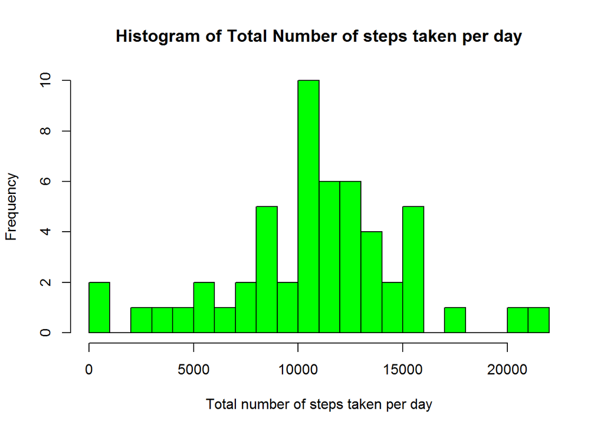

```r
hist(spd$steps,
     col = "green",
     main = "Histogram of Total Number of steps taken per day",
     xlab = "Total number of steps taken per day",
     breaks = 20
     )
```

- Calculate and report the mean and median of the total number of steps taken per day

According to data subset which gives spd database, the mean of total number of steps taken per day is :

```r
mean(spd$steps)
```

```
## [1] 10766.19
```

And the median is :

```r
median(spd$steps)
```

```
## [1] 10765
```

#### 3.What is the average daily activity pattern?

- Make a time series plot (i.e. type = “l”) of the 5-minute interval (x-axis) and the average number of steps taken, averaged across all days (y-axis)

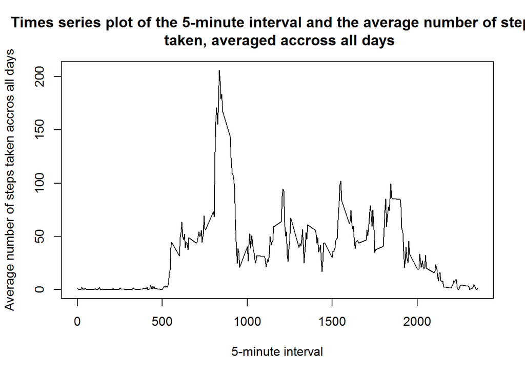

```r
si <- aggregate(steps ~ interval, activity_na, mean)
plot(
        x=si$interval,
        y=si$steps,
        type="l",
        main="Times series plot of the 5-minute interval and the average number of steps \n taken, averaged accross all days",
        xlab="5-minute interval",
        ylab="Average number of steps taken accros all days")
```

- Which 5-minute interval, on average across all the days in the dataset, contains the maximum number of steps?

```r
si[si$steps==max(si$steps),]
```

```
##     interval    steps
## 104      835 206.1698
```

#### 4. Imputing missing values

- Calculate and report the total number of missing values in the dataset (i.e. the total number of rows with NAs)

```r
nrow(activity[is.na(activity$steps),])
```

```
## [1] 2304
```

According to results, the activity database have 2304 NA values.

- Devise a strategy for filling in all of the missing values in the dataset.

For filling in all of the missing values in the dataset, we will use the mean of the 5-mn interval for that.

- Create a new dataset that is equal to the original dataset but with the missing data filled in.

```r
nactivity <-activity
nNa <- is.na(nactivity$steps)
si <- tapply(activity_na$steps, activity_na$interval, mean, na.rm=T, simplify=T)
nactivity$steps[nNa] <- si[as.character(nactivity$interval[nNa])]
```

- Make a histogram of the total number of steps taken each day and Calculate and report the mean and median total number of steps taken per day. Do these values differ from the estimates from the first part of the assignment? What is the impact of imputing missing data on the estimates of the total daily number of steps?

```r
sd <- aggregate(steps ~ date, nactivity, sum)
```

We have same values around filling new database with mean:

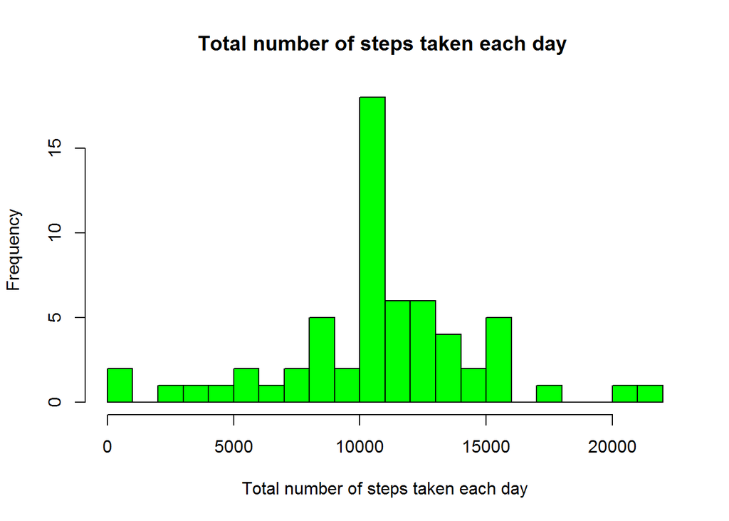

```r
hist(
        sd$steps,
        col="green",
        main="Total number of steps taken each day ",
        xlab="Total number of steps taken each day",
       breaks=20 )
```

The result of mean of steps in new database is given by :

```r
mean(sd$steps)
```

```
## [1] 10766.19
```

Also, the result of median of steps given in new database is given by:

```r
median(sd$steps)
```

```
## [1] 10766.19
```

According to the results, difference are smalls between this values and those of the first part of assignment. For the mean, we get the same value 10766.19. And for the median, we get 10766 against 10765 for the first part which is sensibly the same. The impact of imputing missing data on the estimates of the total daily number of steps don’t change significantly results of descriptive statistics of the variable.

#### 5.Are there differences in activity patterns between weekdays and weekends?

*Create a new factor variable in the dataset with two levels - “weekday” and “weekend” indicating whether a given date is a weekday or weekend day.

```r
nnactivity <- nactivity
weekend <- weekdays(as.Date(nnactivity$date))%in% c("Saturday", "Sunday")
nnactivity$dw <- "weekday"
nnactivity$dw[weekend==TRUE] <- "weekend"
nnactivity$dw <- as.factor(nnactivity$dw)
```

- Make a panel plot containing a time series plot (i.e. type = “l”) of the 5-minute interval (x-axis) and the average number of steps taken, averaged across all weekday days or weekend days (y-axis). See the README file in the GitHub repository to see an example of what this plot should look like using simulated data.

```r
sid <- aggregate(steps ~ interval + dw, nnactivity, mean)
```

[figure not shown]

```r
library(lattice)
xyplot(
        steps ~ interval | dw,
        sid,
        type = "l",
        layout = c(1,2),
        main = "Time series plot \n of the 5 minute interval and the average\n  number of steps taken average \n accross all weekdays or weekend days",
        xlab = "5 minute interval",
        ylab = "Average number of steps taken",
        lty = 1
        )
```